# Lab6_Sabrina_Zhang

Author

Sabrina_Zhang

## Prepair and import data

```r
library(tidyverse)
library(tidytext)
library(readr)
library(dplyr)
mt_samples <- read_csv("https://raw.githubusercontent.com/USCbiostats/data-science-data/master/00_mtsamples/mtsamples.csv")
```

```
──────────────────────────────────────────────────────── Delimiter: "," chr
(5): description, medical_specialty, sample_name, transcription, keywords dbl
(1): ...1
```

```r
mt_samples <- mt_samples |>
  select(description, medical_specialty, transcription)

head(mt_samples)
```

```
# A tibble: 6 × 3
  description                                    medical_specialty transcription
  <chr>                                          <chr>             <chr>
1 A 23-year-old white female presents with comp… Allergy / Immuno… "SUBJECTIVE:…
2 Consult for laparoscopic gastric bypass.       Bariatrics        "PAST MEDICA…
3 Consult for laparoscopic gastric bypass.       Bariatrics        "HISTORY OF …
4 2-D M-Mode. Doppler.                           Cardiovascular /… "2-D M-MODE:…
5 2-D Echocardiogram                             Cardiovascular /… "1.  The lef…
6 Morbid obesity.  Laparoscopic antecolic anteg… Bariatrics        "PREOPERATIV…
```

## Question 1: What specialties do we have?

```r
mt_samples %>%
  count(medical_specialty, sort = TRUE)
```

```
# A tibble: 40 × 2
   medical_specialty                 n
   <chr>                         <int>
 1 Surgery                        1103
 2 Consult - History and Phy.      516
 3 Cardiovascular / Pulmonary      372
 4 Orthopedic                      355
 5 Radiology                       273
 6 General Medicine                259
 7 Gastroenterology                230
 8 Neurology                       223
 9 SOAP / Chart / Progress Notes   166
10 Obstetrics / Gynecology         160
# ℹ 30 more rows
```

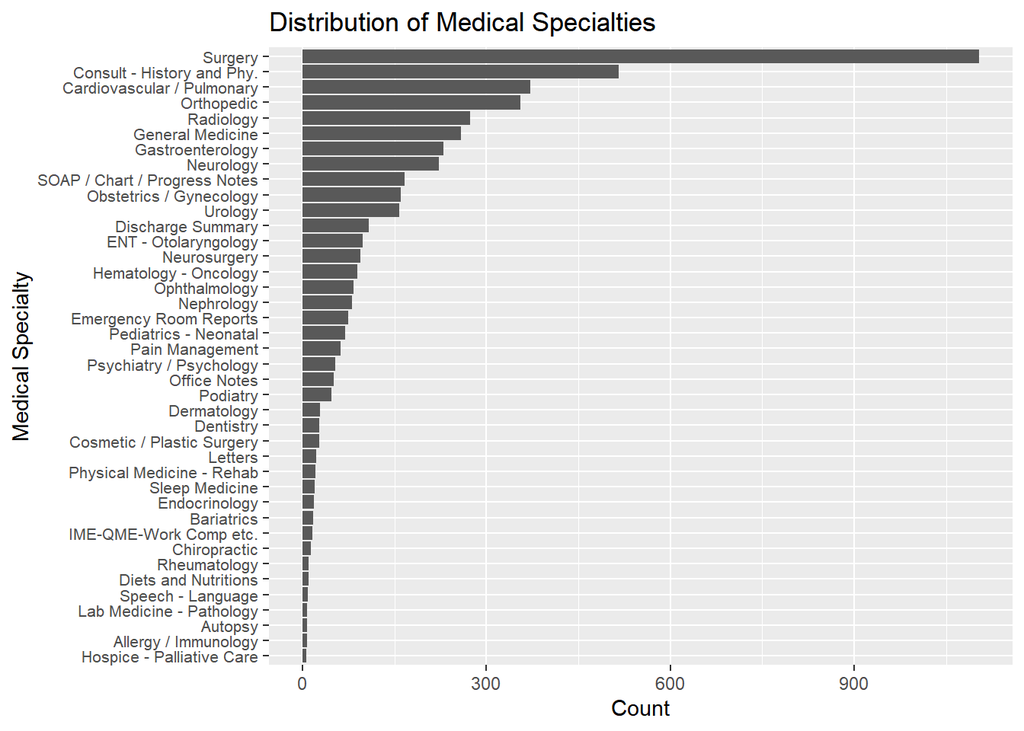

```r
mt_samples %>%
  count(medical_specialty, sort = TRUE) %>%
  ggplot(aes(n, fct_reorder(medical_specialty, n))) +
  geom_col() +
  theme(axis.text.y = element_text(size = 8)) +
  labs(
    title = "Distribution of Medical Specialties",
    x = "Count",
    y = "Medical Specialty"
  )
```

There are 40 specialties across 4,999 samples, and the distribution is very uneven: Surgery alone has 1,103 (about 22%). Several categories overlap in subject, such as Surgery, Orthopedic, and Bariatrics, all of which cover operative care.

## Question 2

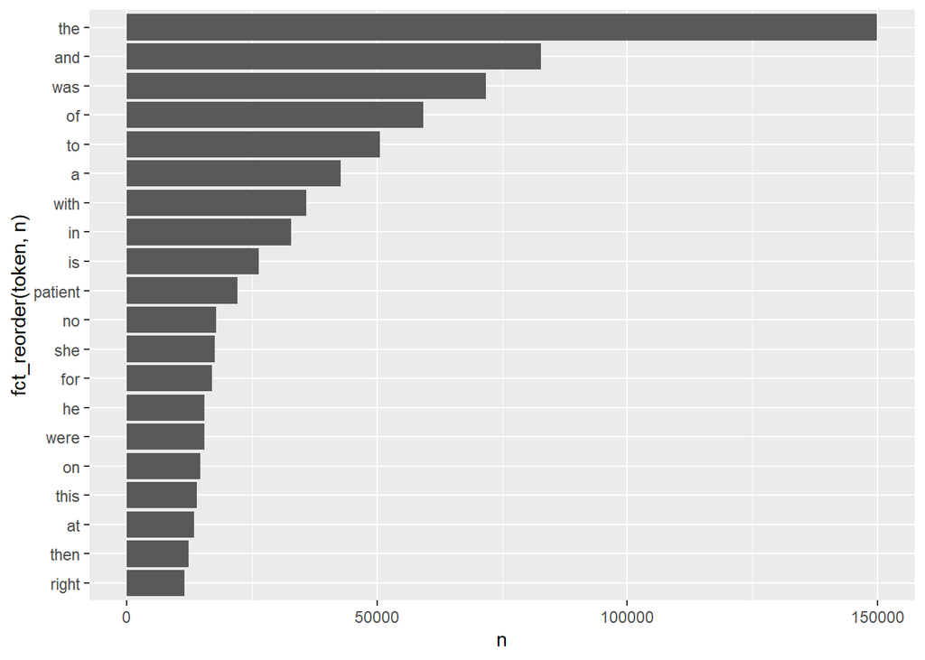

```r
mt_samples |>
  unnest_tokens(token, transcription) |>
  count(token, sort=TRUE) |>
  top_n(20,n) |>
  ggplot(aes(n, fct_reorder(token, n))) +
  geom_col()
```

The top 20 words are almost all function words like “the,” “and,” “was,” and “of.” The only content words that stand out are “patient” and “right”.” This makes sense for narrative clinical notes, but the plot tells us very little about what the notes are about.

## Question 3

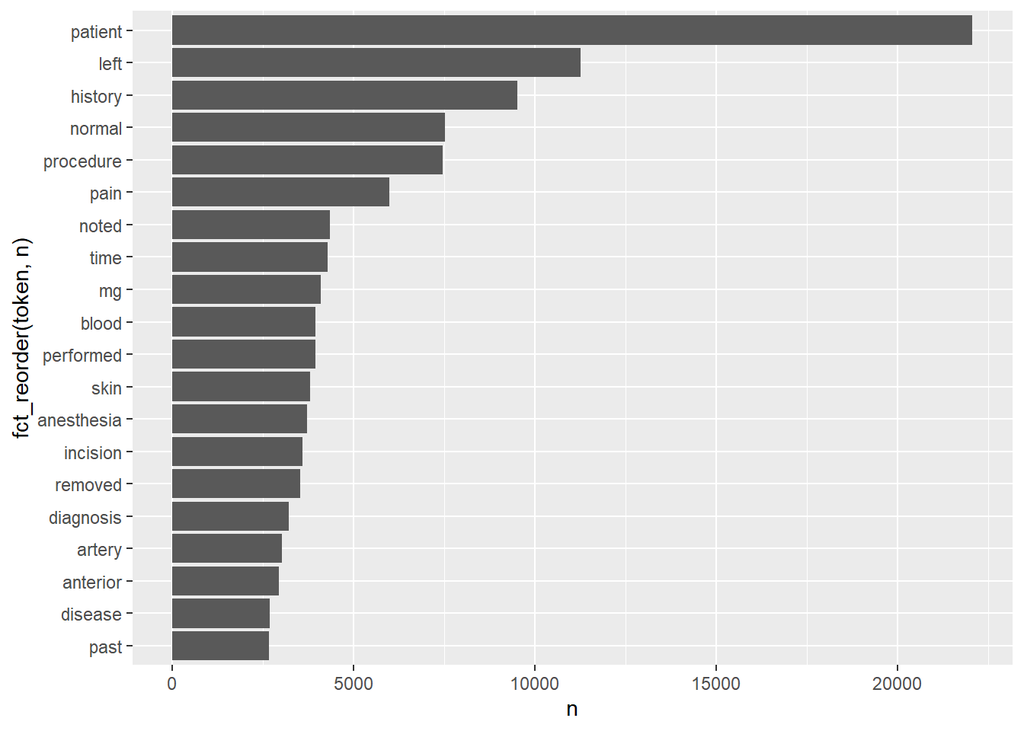

```r
mt_samples |>
  unnest_tokens(token, transcription) |>
  anti_join(stop_words, by = c("token"="word")) |>
  filter(!grepl("^[0-9.]+$", token)) |>   #remove all token of numbers include decimals.
  count(token, sort=TRUE) |>
  top_n(20,n) |>
  ggplot(aes(n, fct_reorder(token, n))) +
  geom_col()
```

## Question 4

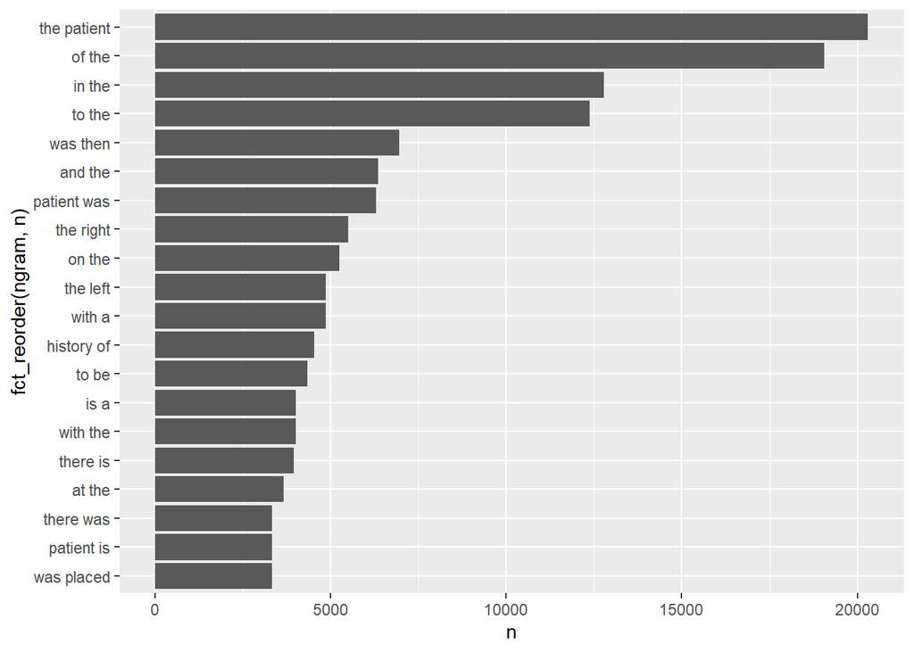

```r
mt_samples |>
  unnest_ngrams(ngram, transcription, n=2) |>
  count(ngram, sort=TRUE) |>
  top_n(20,n) |>
  ggplot(aes(n, fct_reorder(ngram, n))) +
  geom_col()
```

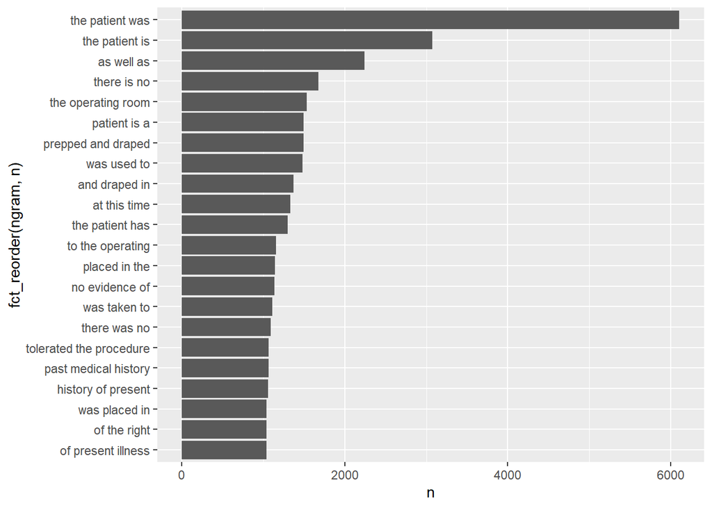

```r
mt_samples |>
  unnest_ngrams(ngram, transcription, n=3) |>
  count(ngram, sort=TRUE) |>
  top_n(20,n) |>
  ggplot(aes(n, fct_reorder(ngram, n))) +
  geom_col()
```

The top bigrams are mostly function word pairs like “the patient” and “of the.” Trigrams are more useful: “the patient was”, “tolerated the procedure,” and “past medical history” are standard phrases from templated clinical notes. Longer n-grams capture more of the document’s structure.

## Question 5

```r
mt_samples|>
  unnest_ngrams(ngram, transcription, n = 2) |>
  separate(ngram, into = c("word1", "word2"), sep = " ") |>
  select(word1, word2) |>
  filter(word1 == "medical") |>
  count(word2, sort = TRUE)
```

```
# A tibble: 97 × 2
   word2          n
   <chr>      <int>
 1 history     1223
 2 center        94
 3 problems      93
 4 therapy       76
 5 records       60
 6 attention     39
 7 management    35
 8 floor         31
 9 record        29
10 treatment     29
# ℹ 87 more rows
```

```r
mt_samples|>
  unnest_ngrams(ngram, transcription, n = 2) |>
  separate(ngram, into = c("word1", "word2"), sep = " ") |>
  select(word1, word2) |>
  filter(word2 == "medical") |>
  count(word1, sort = TRUE)
```

```
# A tibble: 180 × 2
   word1        n
   <chr>    <int>
 1 past      1113
 2 the         88
 3 to          56
 4 multiple    42
 5 other       40
 6 family      38
 7 his         32
 8 general     28
 9 known       24
10 maximum     24
# ℹ 170 more rows
```

“Medical” is almost always followed by “history” (1,223 times) and usually preceded by “past” (1,113 times). In other words, it is mostly part of the fixed heading “past medical history,” not a free-standing content word.

## Question 6

```r
mt_samples |>
  unnest_tokens(token, transcription) |>
  anti_join(stop_words, by = c("token" = "word")) |>
  filter(!grepl("^[0-9.]+$", token)) |>
  count(medical_specialty, token, sort = TRUE) |>
  group_by(medical_specialty) |>
  slice_max(n, n = 5, with_ties = FALSE) |>
  arrange(medical_specialty, desc(n))
```

```
# A tibble: 200 × 3
# Groups:   medical_specialty [40]
   medical_specialty    token         n
   <chr>                <chr>     <int>
 1 Allergy / Immunology history      38
 2 Allergy / Immunology noted        23
 3 Allergy / Immunology patient      22
 4 Allergy / Immunology allergies    21
 5 Allergy / Immunology nasal        13
 6 Autopsy              left         83
 7 Autopsy              inch         59
 8 Autopsy              neck         55
 9 Autopsy              anterior     47
10 Autopsy              body         40
# ℹ 190 more rows
```

After removing stop words, each specialty has its own vocabulary. Allergy / Immunology’s top words include “allergies” and “nasal,” while Autopsy’s include “neck,” “anterior,” and “body.” Thus, the specialty-specific terms are the more informative ones.

## Question 7

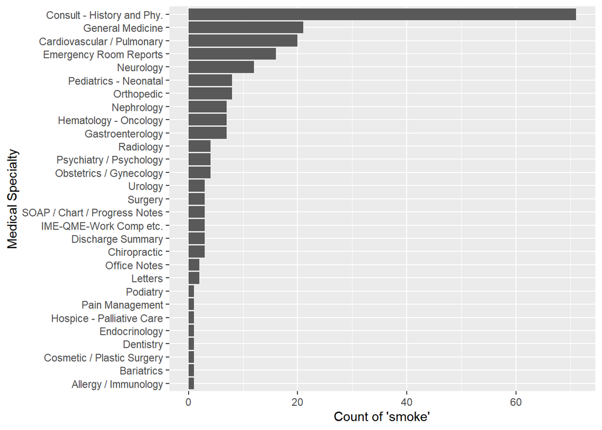

```r
mt_samples |>
  unnest_tokens(token, transcription) |>
  filter(token == "smoke") |>
  count(medical_specialty, sort = TRUE) |>
  ggplot(aes(n, fct_reorder(medical_specialty, n))) +
  geom_col() +
  labs(x = "Count of 'smoke'", y = "Medical Specialty")
```

The word “smoke” shows up most often in Consult - History and Phy. notes (about 72 times). These notes usually include a social history, which is probably why. General Medicine (about 21), Cardiovascular / Pulmonary (about 20), and Emergency Room Reports (about 16) come next. Most other specialties have 10 or fewer mentions.

This chart shows raw counts, so specialties with more notes will naturally show higher numbers.

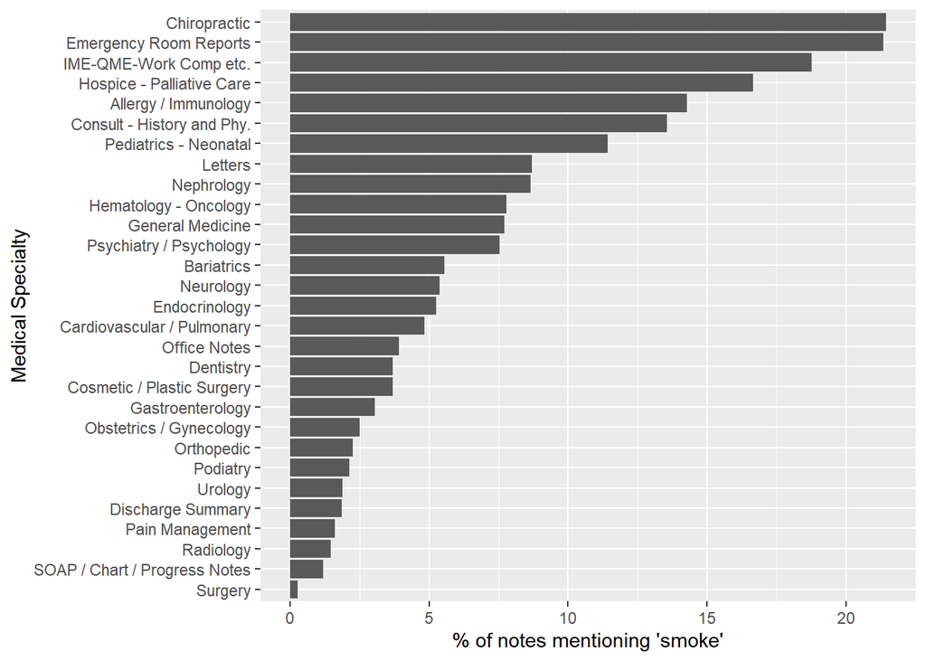

```r
totals <- mt_samples |>
  count(medical_specialty, name = "total")

mt_samples |>
  mutate(id = row_number()) |>
  unnest_tokens(token, transcription) |>
  filter(token == "smoke") |>
  distinct(id, medical_specialty) |>
  count(medical_specialty, name = "smoke_notes") |>
  left_join(totals, by = "medical_specialty") |>
  mutate(pct = smoke_notes / total * 100) |>
  arrange(desc(pct)) |>
  ggplot(aes(pct, fct_reorder(medical_specialty, pct))) +
  geom_col() +
  labs(x = "% of notes mentioning 'smoke'", y = "Medical Specialty")
```

When we look at the share of notes that mention “smoke,” the ranking changes a lot. Chiropractic and Emergency Room Reports are highest, at about 21% each, followed by IME-QME-Work Comp (about 19%) and Hospice - Palliative Care (about 17%). Consult - History and Phy. is about 14%, which is much lower than its raw count suggested. Surgery is near 0%.